# Exploraciones sobre la Encuesta de consumos culturales

```r
library(tidyverse)
library(arules)
```

Lectura de los datos de la encuesta

```r
encuesta <- read.csv('/Users/javierspina/Documents/jspina/ecyt-introcsdatos/tp_consumo_cultural/encc_2017_pars.csv')
head(encuesta)
```

|  | X | id | pondera_dem | fecha | region | sexo | edad | significado_cultura | otro_significado_cultura | escucha_radio | motivo_no_escucha_radio | otro_motivo_no_escucha_radio | acostumbraba_escuchar_radio | escucha_radio_online | frec_escucha_radio | am_o_fm | escucha_radio_horas | escucha_radio_minutos | horas_radio | minutos_radio | radio_equipo_estereo | radio_auto | radio_computadora | radio_celular | radio_tablet | tipo_programa_radio_a | tipo_programa_radio_b | tipo_programa_radio_c | tipo_programa_radio_d | … |
| --- | --- | --- | --- | --- | --- | --- | --- | --- | --- | --- | --- | --- | --- | --- | --- | --- | --- | --- | --- | --- | --- | --- | --- | --- | --- | --- | --- | --- | --- | --- |
| 1 | 0 | 1 | 8608 | 23/5/2017 | CENTRO | Varón | 19 | LA FORMA DE PENSAR, IDEOLOGIA, VALORES |  | SI |  |  |  | SI | ALGUNAS VECES AL MES | FM | 1 | 0 | 1 | 0 | ALGUNAS VECES AL MES | NUNCA | NUNCA | ALGUNAS VECES AL MES | NUNCA | MUSICALES | ACTUALIDAD / MAGAZINE |  |  | … |
| 2 | 1 | 2 | 2869 | 10/5/2017 | CENTRO | Varón | 24 | EL ARTE, LO CULTO |  | SI |  |  |  | NO | ALGUNOS DIAS POR SEMANA | FM | 1 | 0 | 1 | 0 | ALGUNOS DIAS POR SEMANA | ALGUNOS DIAS POR SEMANA | NUNCA | ALGUNOS DIAS POR SEMANA | NUNCA | INFORMATIVOS / NOTICIEROS | MUSICALES | CULTURALES |  | … |
| 3 | 2 | 3 | 8765 | 22/5/2017 | CENTRO | Varón | 30 | LA FORMA DE PENSAR, IDEOLOGIA, VALORES |  | SI |  |  |  | NO | ALGUNOS DIAS POR SEMANA | FM | 1 | 30 | 1 | 30 | NUNCA | TODOS O CASI TODOS LOS DIAS | NUNCA | ALGUNOS DIAS POR SEMANA | NUNCA | INFORMATIVOS / NOTICIEROS | ACTUALIDAD / MAGAZINE |  |  | … |
| 4 | 3 | 4 | 12838 | 9/5/2017 | CENTRO | Varón | 53 | MUSICA |  | SI |  |  |  | SI | TODOS O CASI TODOS LOS DIAS | AMBAS POR IGUAL | 3 | 0 | 3 | 0 | TODOS O CASI TODOS LOS DIAS | ALGUNOS DIAS POR SEMANA | ALGUNAS VECES AL MES | TODOS O CASI TODOS LOS DIAS | NUNCA | INFORMATIVOS / NOTICIEROS | ACTUALIDAD / MAGAZINE |  |  | … |
| 5 | 4 | 5 | 20223 | 22/5/2017 | CENTRO | Varón | 70 | LA FORMA DE PENSAR, IDEOLOGIA, VALORES |  | SI |  |  |  | NO | TODOS O CASI TODOS LOS DIAS | AMBAS POR IGUAL | 3 | 0 | 3 | 0 | TODOS O CASI TODOS LOS DIAS | ALGUNOS DIAS POR SEMANA | NUNCA | NUNCA | NUNCA | INFORMATIVOS / NOTICIEROS | ACTUALIDAD / MAGAZINE |  |  | … |
| 6 | 5 | 6 | 5474 | 9/5/2017 | CENTRO | Mujer | 15 | LA TRADICION, LA HISTORIA |  | SI |  |  |  | NO | TODOS O CASI TODOS LOS DIAS | FM | 2 | 0 | 2 | 0 | TODOS O CASI TODOS LOS DIAS | NUNCA | NUNCA | NUNCA | NUNCA | INFORMATIVOS / NOTICIEROS | MUSICALES |  |  | … |

Adecuación de los datos

```r
encuesta$X <- NULL
encuesta <- encuesta[-c(1950, 2740),]
```

Agregamos rango etario

```r
encuesta <- encuesta %>% mutate(rango_etario = case_when(
  edad <= 20 ~ 'Entre 13 y 20',
  edad <= 28 ~ 'Entre 21 y 28',
  edad <= 36 ~ 'Entre 29 y 36',
  edad <= 44 ~ 'Entre 37 y 44',
  edad <= 52 ~ 'Entre 45 y 52',
  edad <= 60 ~ 'Entre 53 y 60',
  edad <= 68 ~ 'Entre 61 y 68',
  edad <= 76 ~ 'Entre 69 y 76',
  edad <= 84 ~ 'Entre 77 y 84',
  edad > 84 ~ '85 o más',
  TRUE ~ NA_character_
))
```

Crear primera versión más chica del dataset

```r
encuesta_corta_1 <- select(encuesta, id, pondera_dem, region, sexo, rango_etario, escucha_radio, escucha_radio_online, escucha_musica, musica_desde_internet, concurre_recitales, practica_musica, lee_diarios, lee_revistas, lee_libros, miro_tv, concurre_cine, concurre_teatro, usa_internet, usa_aplicaciones, tiene_facebook, tiene_instagram, tiene_twitter, tiene_snapchat, tiene_linkedin, juega_videojuegos, NSEcat1)

encuesta_corta_1$id <- as.integer(encuesta_corta_1$id)
encuesta_corta_1$pondera_dem <- as.integer(encuesta_corta_1$pondera_dem)
encuesta_corta_1[sapply(encuesta_corta_1, is.character)] = lapply(encuesta_corta_1[sapply(encuesta_corta_1, is.character)], as.factor)
```

Reglas de asociación para la primera versión de la encuesta corta

```r
rules_1 <- apriori(encuesta_corta_1, parameter = c(minlen=3, confidence=0.7))
```

```
## Apriori
##
## Parameter specification:
##  confidence minval smax arem  aval originalSupport maxtime support minlen
##         0.7    0.1    1 none FALSE            TRUE       5     0.1      3
##  maxlen target  ext
##      10  rules TRUE
##
## Algorithmic control:
##  filter tree heap memopt load sort verbose
##     0.1 TRUE TRUE  FALSE TRUE    2    TRUE
##
## Absolute minimum support count: 280
##
## set item appearances ...[0 item(s)] done [0.00s].
## set transactions ...[83 item(s), 2800 transaction(s)] done [0.01s].
## sorting and recoding items ... [67 item(s)] done [0.00s].
## creating transaction tree ... done [0.00s].
## checking subsets of size 1 2 3 4 5 6 7 8 9 10
```

```
##  done [4.28s].
## writing ... [3759213 rule(s)] done [0.54s].
## creating S4 object  ... done [1.49s].
```

```r
summary(rules_1)
```

```
## set of 3759213 rules
##
## rule length distribution (lhs + rhs):sizes
##      3      4      5      6      7      8      9     10
##  10313  67293 245311 557711 853469 920745 712643 391728
##
##    Min. 1st Qu.  Median    Mean 3rd Qu.    Max.
##   3.000   7.000   8.000   7.593   9.000  10.000
##
## summary of quality measures:
##     support         confidence        coverage           lift
##  Min.   :0.1000   Min.   :0.7000   Min.   :0.1000   Min.   :0.7987
##  1st Qu.:0.1089   1st Qu.:0.8430   1st Qu.:0.1182   1st Qu.:1.0430
##  Median :0.1214   Median :0.9375   Median :0.1364   Median :1.2098
##  Mean   :0.1366   Mean   :0.9084   Mean   :0.1520   Mean   :1.4790
##  3rd Qu.:0.1471   3rd Qu.:0.9847   3rd Qu.:0.1664   3rd Qu.:1.2906
##  Max.   :0.7675   Max.   :1.0000   Max.   :0.8736   Max.   :5.4581
##      count
##  Min.   : 280.0
##  1st Qu.: 305.0
##  Median : 340.0
##  Mean   : 382.4
##  3rd Qu.: 412.0
##  Max.   :2149.0
##
## mining info:
##              data ntransactions support confidence
##  encuesta_corta_1          2800     0.1        0.7
##                                                                           call
##  apriori(data = encuesta_corta_1, parameter = c(minlen = 3, confidence = 0.7))
```

Vemos de esta primera versión, las asociaciones que tienen más valor de confianza

```r
inspect(sort(rules_1, by='confidence', decreasing = T)[1:5])
```

```
##     lhs                              rhs                   support confidence  coverage     lift count
## [1] {tiene_facebook=NO,
##      tiene_instagram=NO}          => {tiene_snapchat=NO} 0.1057143          1 0.1057143 1.384083   296
## [2] {tiene_facebook=NO,
##      tiene_twitter=NO}            => {tiene_snapchat=NO} 0.1103571          1 0.1103571 1.384083   309
## [3] {concurre_teatro=SI,
##      usa_internet=SI}             => {usa_aplicaciones=} 0.1114286          1 0.1114286 1.288541   312
## [4] {concurre_teatro=SI,
##      usa_aplicaciones=}           => {usa_internet=SI}   0.1114286          1 0.1114286 1.288541   312
## [5] {rango_etario=Entre 29 y 36,
##      usa_internet=SI}             => {usa_aplicaciones=} 0.1171429          1 0.1171429 1.288541   328
```

Podríamos elegir una versión corta que evite id y otros campos que parecen hacer ruido, como el usa_aplicaciones que es redundante con los tiene_. Se deja edad, región y NSEcat1 que es el nivel socio-económico.

```r
encuesta_corta_2 <- select(encuesta, region, sexo, rango_etario, escucha_radio, escucha_musica, concurre_recitales, lee_diarios, lee_revistas, lee_libros, miro_tv, concurre_cine, concurre_teatro, usa_internet, juega_videojuegos, concurre_boliches, concurre_museo, NSEcat1)

encuesta_corta_2[sapply(encuesta_corta_2, is.character)] = lapply(encuesta_corta_2[sapply(encuesta_corta_2, is.character)], as.factor)
```

```r
rules_2 <- apriori(encuesta_corta_2, parameter = c(minlen=3, confidence=0.6, support=0.07))
```

```
## Apriori
##
## Parameter specification:
##  confidence minval smax arem  aval originalSupport maxtime support minlen
##         0.6    0.1    1 none FALSE            TRUE       5    0.07      3
##  maxlen target  ext
##      10  rules TRUE
##
## Algorithmic control:
##  filter tree heap memopt load sort verbose
##     0.1 TRUE TRUE  FALSE TRUE    2    TRUE
##
## Absolute minimum support count: 196
##
## set item appearances ...[0 item(s)] done [0.00s].
## set transactions ...[55 item(s), 2800 transaction(s)] done [0.00s].
## sorting and recoding items ... [46 item(s)] done [0.00s].
## creating transaction tree ... done [0.00s].
## checking subsets of size 1 2 3 4 5 6 7 8 9 10
```

```
##  done [0.20s].
## writing ... [200011 rule(s)] done [0.08s].
## creating S4 object  ... done [0.15s].
```

```r
summary(rules_2)
```

```
## set of 200011 rules
##
## rule length distribution (lhs + rhs):sizes
##     3     4     5     6     7     8     9    10
##  4264 17590 40055 55437 47629 25676  8126  1234
##
##    Min. 1st Qu.  Median    Mean 3rd Qu.    Max.
##   3.000   5.000   6.000   6.201   7.000  10.000
##
## summary of quality measures:
##     support          confidence        coverage            lift
##  Min.   :0.07036   Min.   :0.6000   Min.   :0.07036   Min.   :0.7114
##  1st Qu.:0.08036   1st Qu.:0.7390   1st Qu.:0.09679   1st Qu.:1.0017
##  Median :0.09679   Median :0.8533   Median :0.11964   Median :1.0623
##  Mean   :0.11609   Mean   :0.8328   Mean   :0.14224   Mean   :1.0837
##  3rd Qu.:0.12929   3rd Qu.:0.9371   3rd Qu.:0.16036   3rd Qu.:1.1411
##  Max.   :0.76750   Max.   :1.0000   Max.   :0.87357   Max.   :3.3324
##      count
##  Min.   : 197
##  1st Qu.: 225
##  Median : 271
##  Mean   : 325
##  3rd Qu.: 362
##  Max.   :2149
##
## mining info:
##              data ntransactions support confidence
##  encuesta_corta_2          2800    0.07        0.6
##                                                                                           call
##  apriori(data = encuesta_corta_2, parameter = c(minlen = 3, confidence = 0.6, support = 0.07))
```

Veamos las asociaciones que tienen más valor de confianza

```r
inspect(sort(rules_2, by='confidence', decreasing = T)[1:5])
```

```
##     lhs                              rhs                    support confidence   coverage     lift count
## [1] {concurre_recitales=SI,
##      juega_videojuegos=SI}        => {escucha_musica=SI} 0.08250000          1 0.08250000 1.084851   231
## [2] {rango_etario=Entre 13 y 20,
##      lee_libros=SI,
##      concurre_boliches=SI}        => {escucha_musica=SI} 0.08714286          1 0.08714286 1.084851   244
## [3] {rango_etario=Entre 13 y 20,
##      escucha_radio=SI,
##      concurre_boliches=SI}        => {escucha_musica=SI} 0.07392857          1 0.07392857 1.084851   207
## [4] {rango_etario=Entre 13 y 20,
##      escucha_radio=SI,
##      lee_libros=SI}               => {escucha_musica=SI} 0.07535714          1 0.07535714 1.084851   211
## [5] {concurre_recitales=SI,
##      usa_internet=SI,
##      juega_videojuegos=SI}        => {escucha_musica=SI} 0.08107143          1 0.08107143 1.084851   227
```

Tienen confianza igual a 1, pero el lift es muy bajo. Si se ordena por lift…

```r
inspect(sort(rules_2, by='lift', decreasing = T)[1:5])
```

```
##     lhs                              rhs                       support confidence   coverage     lift count
## [1] {concurre_teatro=NO,
##      juega_videojuegos=NO,
##      concurre_boliches=NO,
##      NSEcat1=D2}                  => {usa_internet=NO}      0.07035714  0.7462121 0.09428571 3.332367   197
## [2] {sexo=Varón,
##      rango_etario=Entre 13 y 20,
##      miro_tv=SI,
##      usa_internet=SI}             => {juega_videojuegos=SI} 0.07857143  0.7719298 0.10178571 3.325236   220
## [3] {sexo=Varón,
##      rango_etario=Entre 13 y 20,
##      escucha_musica=SI,
##      miro_tv=SI,
##      usa_internet=SI}             => {juega_videojuegos=SI} 0.07678571  0.7678571 0.10000000 3.307692   215
## [4] {sexo=Varón,
##      rango_etario=Entre 13 y 20,
##      miro_tv=SI,
##      concurre_teatro=NO,
##      usa_internet=SI}             => {juega_videojuegos=SI} 0.07285714  0.7640449 0.09535714 3.291271   204
## [5] {juega_videojuegos=NO,
##      concurre_boliches=NO,
##      NSEcat1=D2}                  => {usa_internet=NO}      0.07178571  0.7362637 0.09750000 3.287940   201
```

A ver por support…

```r
inspect(sort(rules_2, by='support', decreasing = T)[1:5])
```

```
##     lhs                                        rhs                  support
## [1] {escucha_musica=SI, concurre_teatro=NO} => {miro_tv=SI}         0.7675000
## [2] {miro_tv=SI, concurre_teatro=NO}        => {escucha_musica=SI}  0.7675000
## [3] {escucha_musica=SI, miro_tv=SI}         => {concurre_teatro=NO} 0.7675000
## [4] {concurre_teatro=NO, concurre_museo=NO} => {miro_tv=SI}         0.7403571
## [5] {miro_tv=SI, concurre_museo=NO}         => {concurre_teatro=NO} 0.7403571
##     confidence coverage  lift      count
## [1] 0.9534161  0.8050000 1.0054860 2149
## [2] 0.9168089  0.8371429 0.9946009 2149
## [3] 0.8785773  0.8735714 1.0008203 2149
## [4] 0.9539807  0.7760714 1.0060813 2073
## [5] 0.9201065  0.8046429 1.0481279 2073
```

La tercera, {escucha_musica=SI, miro_tv=SI} => {concurre_teatro=NO} parece resumir a la primera {escucha_musica=SI, concurre_teatro=NO} => {miro_tv=SI} y la segunda {miro_tv=SI, concurre_teatro=NO} => {escucha_musica=SI}

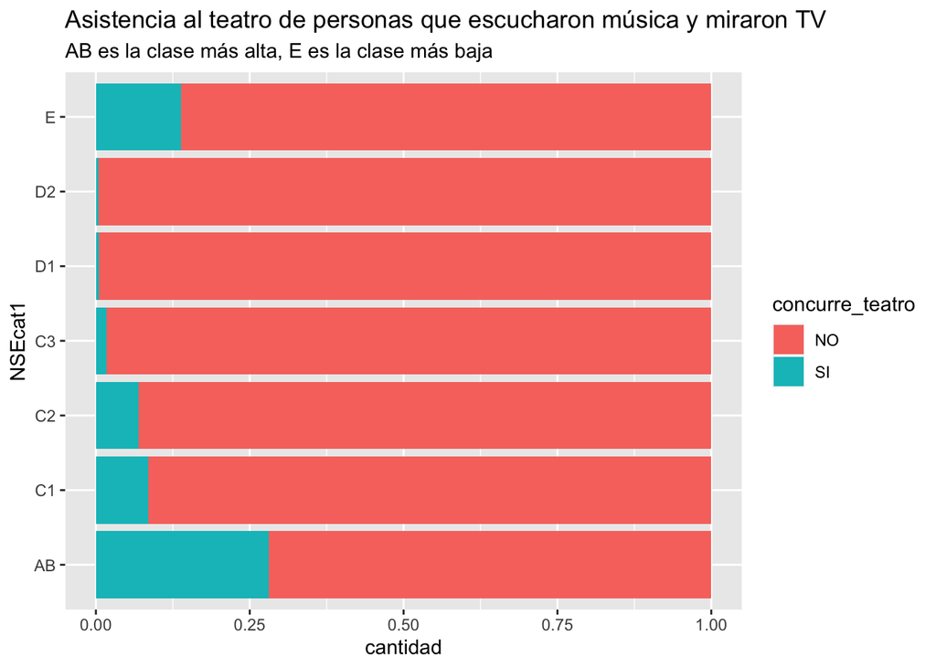

```r
encuesta %>%
  filter(escucha_musica=='SI' & miro_tv=='SI' & NSEcat1 != '') %>%
  group_by(NSEcat1, concurre_teatro) %>%
  mutate(cantidad = n()) %>%
  ggplot() +
  geom_col(aes(x=cantidad, y=NSEcat1, fill=concurre_teatro), position='fill') +
  labs(title='Asistencia al teatro de personas que escucharon música y miraron TV', subtitle='AB es la clase más alta, E es la clase más baja')
```

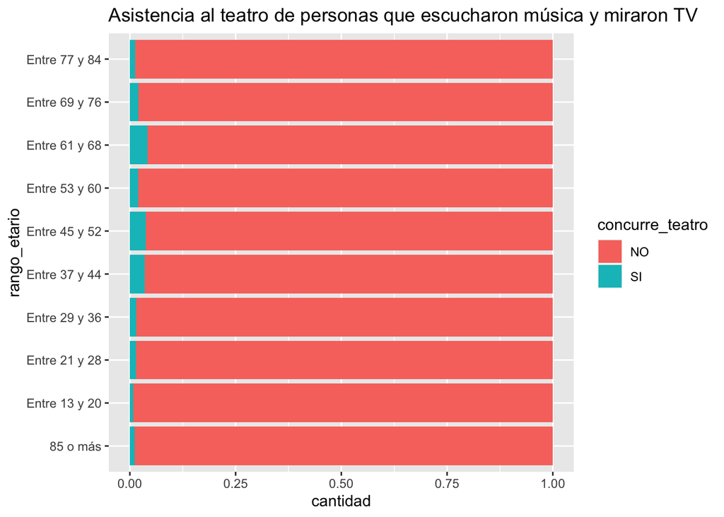

```r
encuesta %>%
  filter(escucha_musica=='SI' & miro_tv=='SI' & NSEcat1 != '') %>%
  group_by(rango_etario, concurre_teatro) %>%
  mutate(cantidad = n()) %>%
  ggplot() +
  geom_col(aes(x=cantidad, y=rango_etario, fill=concurre_teatro), position='fill') +
  labs(title='Asistencia al teatro de personas que escucharon música y miraron TV')
```